# R graphics using ggplot2

2017년 1월 6일

## Introduction

[figure not shown]

**ggplot 2** is an enhanced data visualization package for R.

Create stunning multi-layered graphics with ease

http://docs.ggplot2.org/current

## Why ggplot2? Advantages

- Based on **Grammar of Graphics** (Wilkinson, 2005)
- Flexible
- Theme system for polishing plot appearance

## Grammar of Graphics

- Independent specification of plotting blocks
  - Dataset
  - Aesthetic mapping
  - Geometric object
  - Statistical transformations
  - Scales
  - Coordinate system
  - Position adjustments
  - Faceting

## Basics and Geoms I

## Basic structure

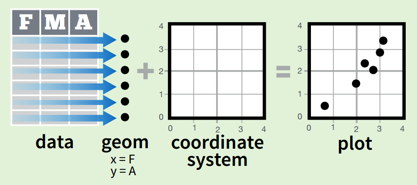

## Preparation

- install and/or update ggplot2 package
- read data file, db/VitDdb_example.csv
- don't forget to check working directory
- check the names of variables
- You can change the names.

```r
# install.packages("ggplot2")
library(ggplot2)
library(dplyr)

# getwd()
db <- read.csv("db/VitDdb_example.csv", header=T)

# names(db)
# str(db)
db <- rename(db,
             TOAST = TOAST.classification,
             prev_mRS = mRS.admission,
             NIHSS = NIHSS.admission)
```

## Geometric objects

- Geometric objects are the actual marks we put on a plot
- A plot must have at least one geom
- Addition of geoms: +
- Examples
  - geom_point(): scatter plots
  - geom_boxplot()

## Aesthetics

- ggplot(dataset, **aes**(x= , y= , color= , size= , and so on))
- **Aesthetic** means *something you can see*.
  - Examples include:
    - position (on the x and y axes)
    - color (outside color)
    - fill(inside color)
    - shape (of point)
    - linetype
    - size
- Each type of geom accepts only a subset of all aesthetics.

## Basic structure 2

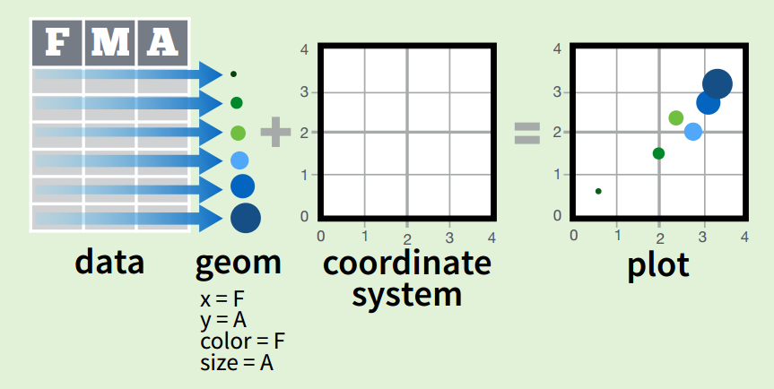

## First example

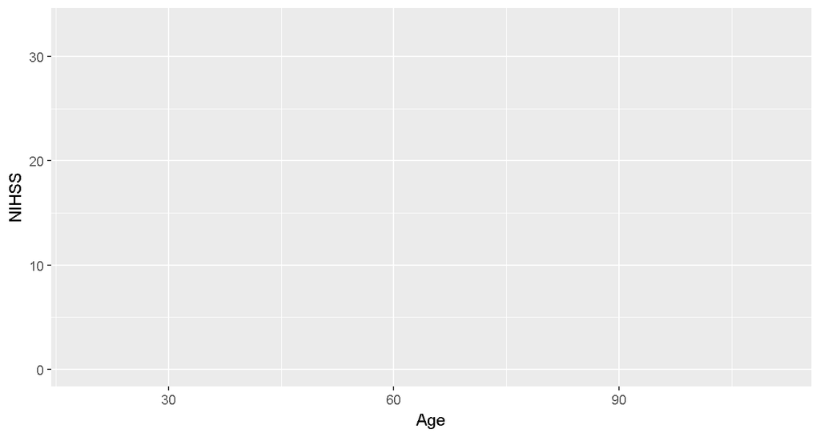

```r
p1 <- ggplot(db, aes(x=Age, y=NIHSS))
p1
```

## Categorical variable

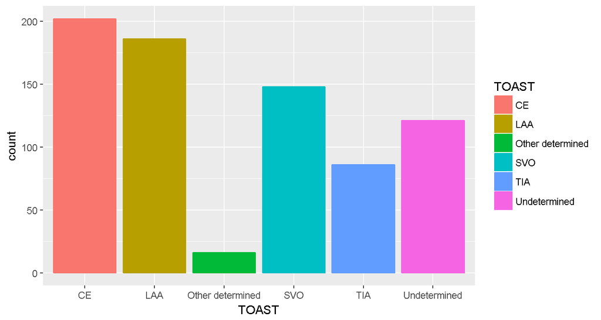

```r
p2 <- ggplot(db, aes(x=TOAST, fill=TOAST, color=TOAST))
p2 + geom_bar()
```

## Categorical variable - change the order of items on X-axis

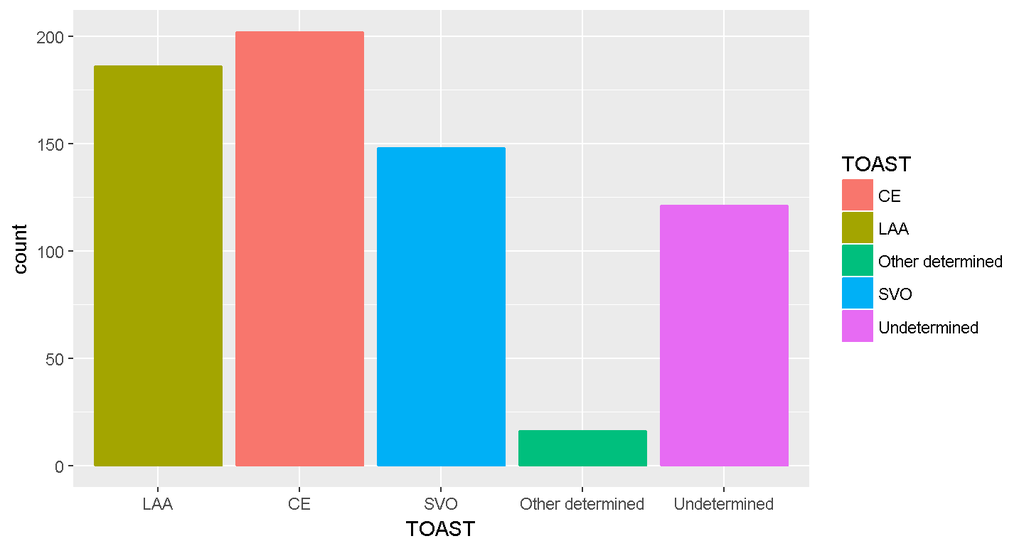

```r
p2 + geom_bar() +
  scale_x_discrete(limits=c("LAA", "CE", "SVO", "Other determined", "Undetermined"))
```

## Continuous variable 1

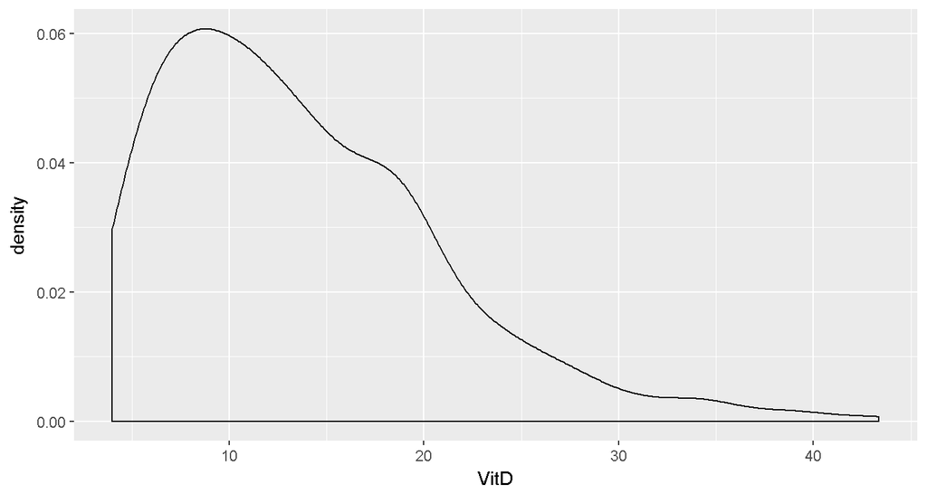

```r
p3 <- ggplot(db, aes(VitD))
p3 + geom_density()
```

## Continuous variable 2

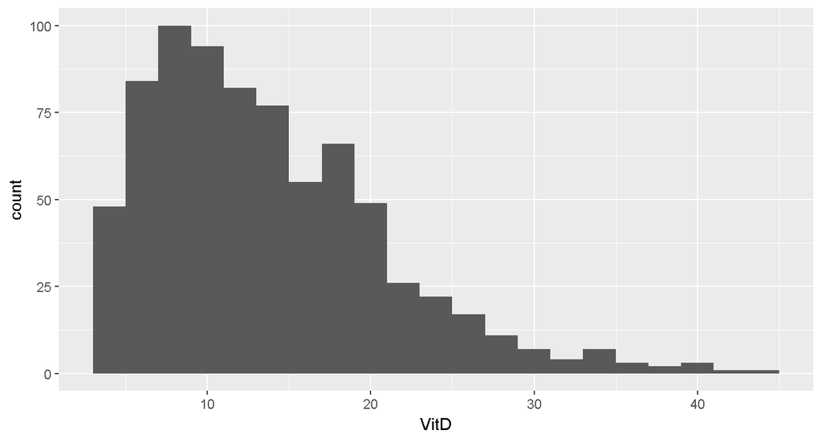

```r
p3 + geom_histogram(binwidth = 2)
```

## Save graph - simple

```r
ggsave("exercise1.png", width = 5, height = 5)
```

## Save graph 2

```r
ppi = 300
tiff("Exercise.tiff", width = ppi*8, height = ppi*4, res = ppi)
p2 + geom_bar()
dev.off()
```

## Exercise 1

- Make a presentation file
  - read your own db file
  - make bar plot of gender
  - you can change the order of items on x-axis
  - make histogram of age.

## Geoms II

## Continuous - continuous 1

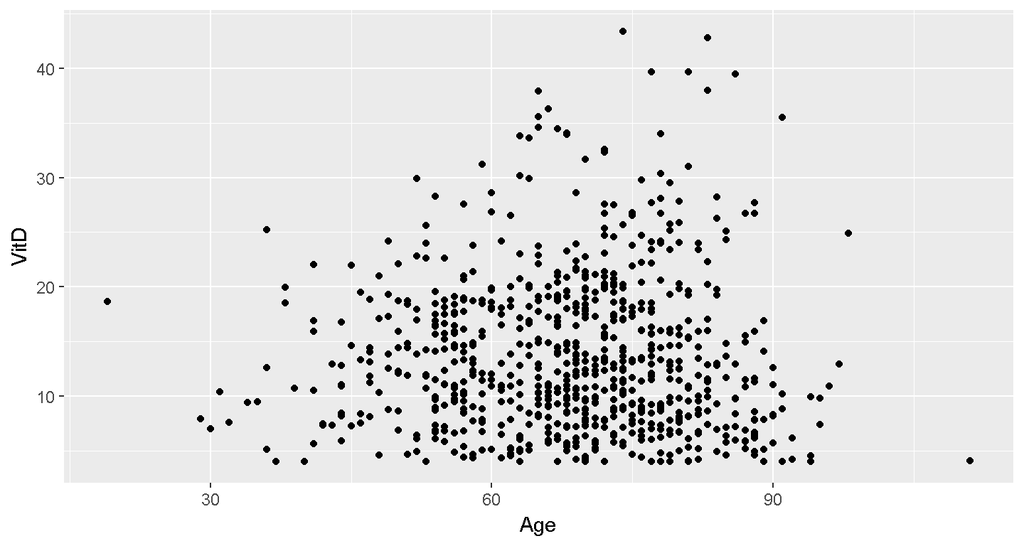

```r
p4 <- ggplot(db, aes(x=Age, y=VitD))
p4 + geom_point()
```

## Continuous - continuous 2

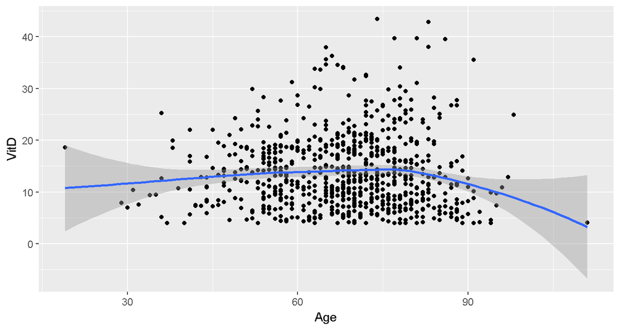

```r
p4 + geom_point() + geom_smooth()
```

## Categorical - continuous 1

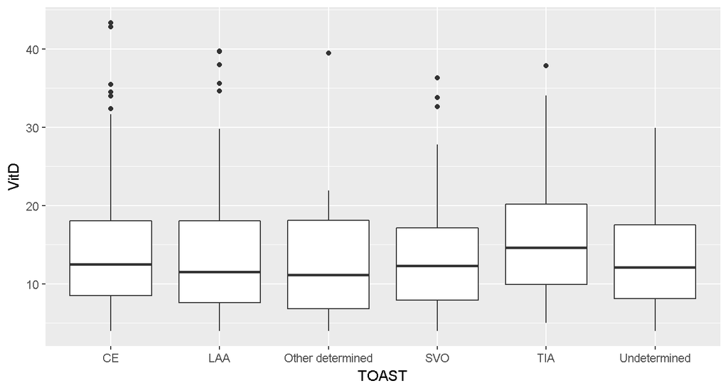

```r
p5 <- ggplot(db, aes(x=TOAST, y=VitD))
p5 + geom_boxplot()
```

## Categorical - continuous 1-1

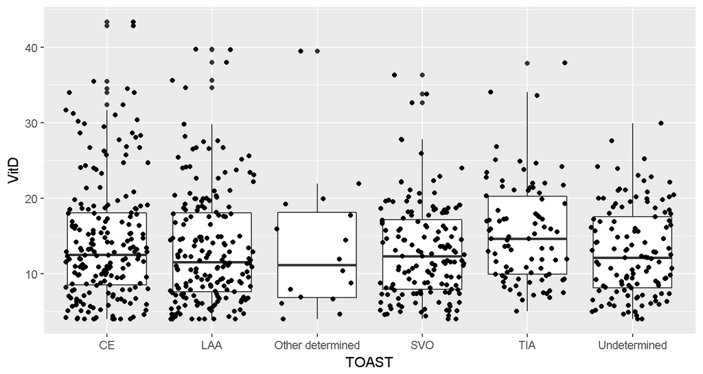

```r
p5 + geom_boxplot() + geom_jitter()
```

## Categorical - continuous 1-2

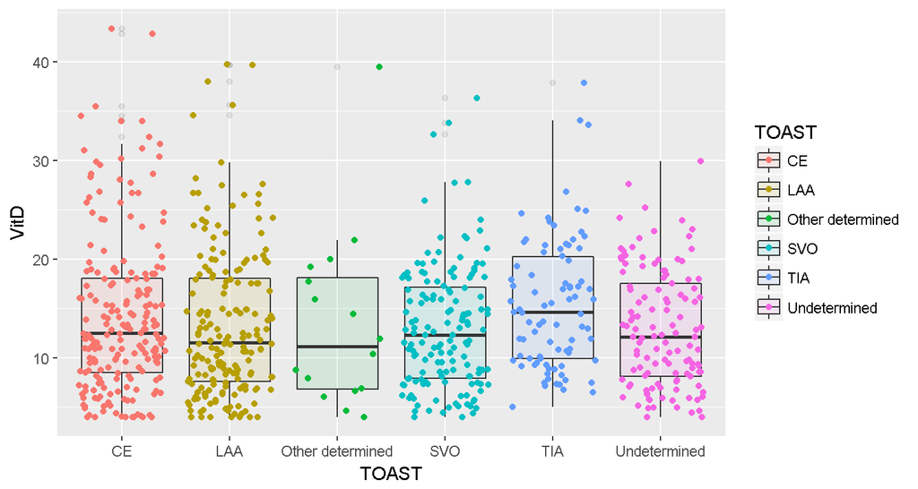

```r
p5 + geom_boxplot(aes(fill=TOAST), alpha=0.1) + geom_jitter(aes(color=TOAST))
```

## Statistical transformation

## Statistical transformation

- Some plot types like scatterplots do not require transformation
- Other plots such as boxplots, histograms, and prediction lines require statistical transformation

## Scale

## Scale

- Include
  - position, color, fill, size, shape, line type
- Arguments
  - name, limits, breaks, labels
- Example
  - scale_*aesthetic*_*type*

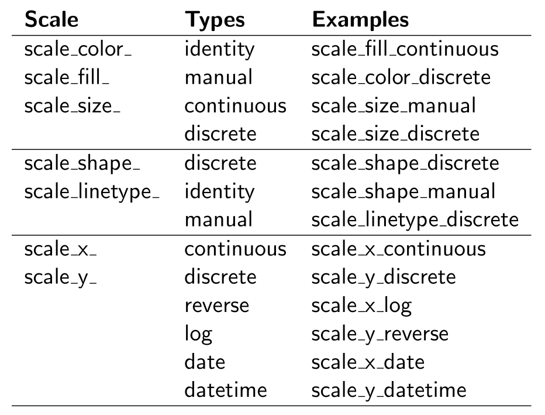

## Scale example

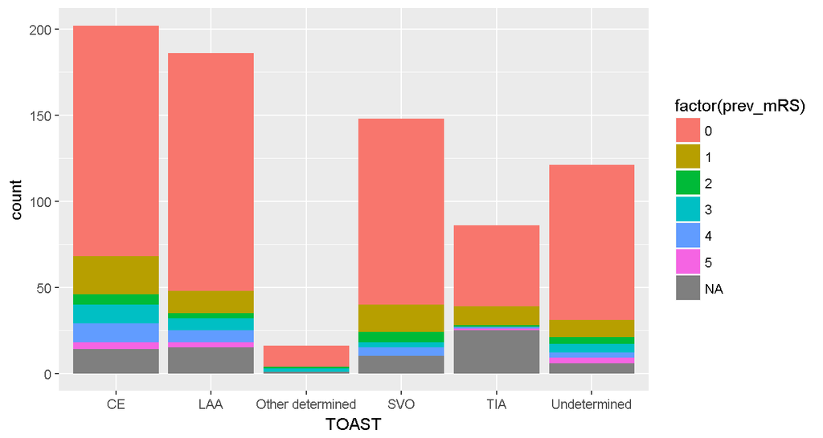

```r
p6 <- ggplot(db, aes(TOAST))
p6 + geom_bar(aes(fill = factor(prev_mRS)))
```

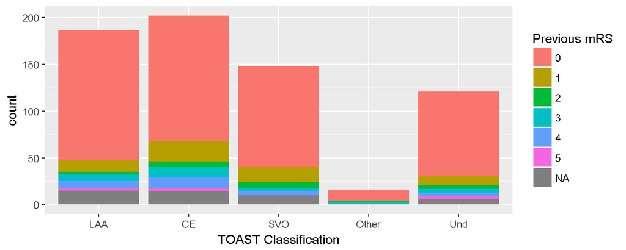

```r
p6 <- ggplot(db, aes(TOAST))
p6 + geom_bar(aes(fill = factor(prev_mRS))) +
  scale_fill_discrete(name = "Previous mRS") +
  scale_x_discrete(name="TOAST Classification",
                   limits=c("LAA", "CE", "SVO", "Other determined", "Undetermined"),
                   breaks=c("LAA", "CE", "SVO", "Other determined", "Undetermined"),
                   labels=c("LAA", "CE", "SVO", "Other", "Und"))
```

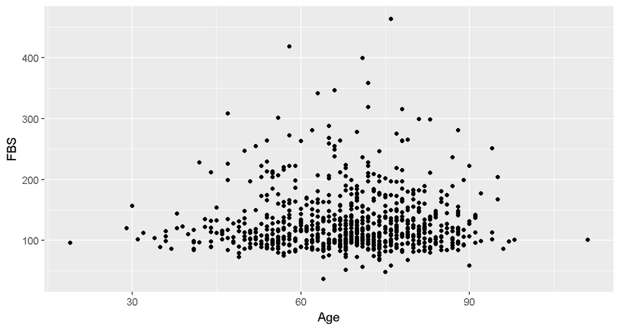

```r
p7 <- ggplot(db, aes(x=Age, y=FBS))
p7 + geom_point()
```

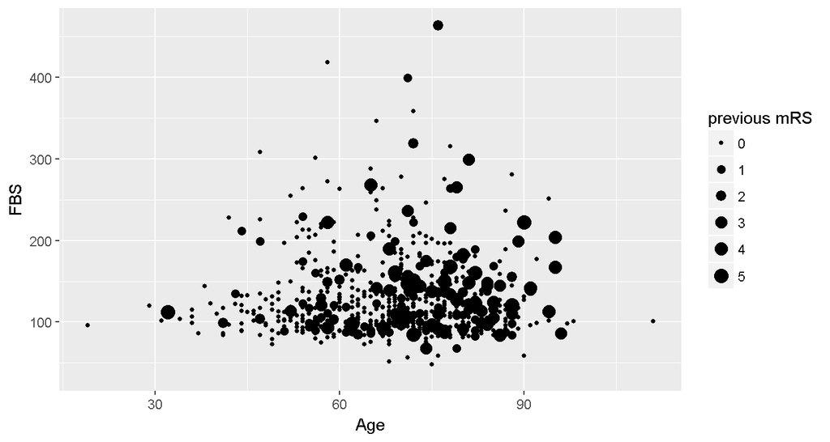

```r
p7 + geom_point(aes(size=prev_mRS)) +
  scale_size_continuous(name="previous mRS", range=c(1, 4))
```

## Faceting

## Faceting

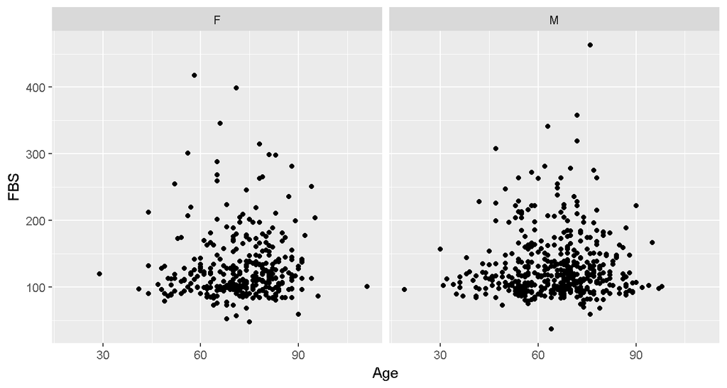

```r
p7 <- ggplot(db, aes(x=Age, y=FBS))
p7 + geom_point() + facet_wrap(~Gender_F)
```

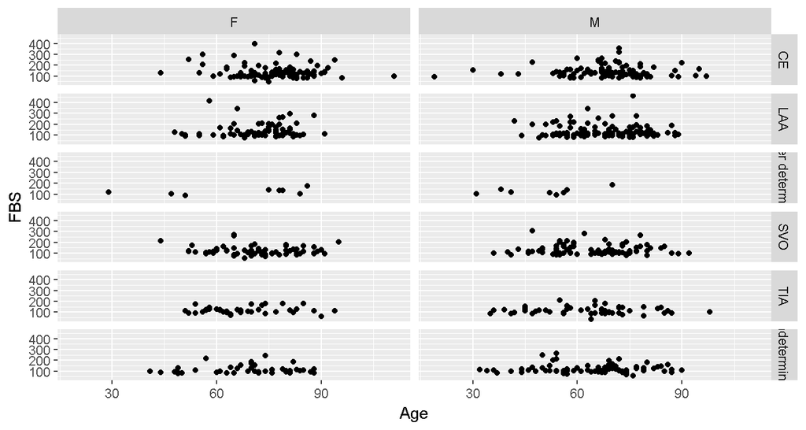

```r
p7 + geom_point() + facet_grid(TOAST~Gender_F)
```

## Theme and label

## Theme

- The theme system handles non-data plot elements
  - Axis labels
  - Plot background
  - Facet label background
  - Legend appearance

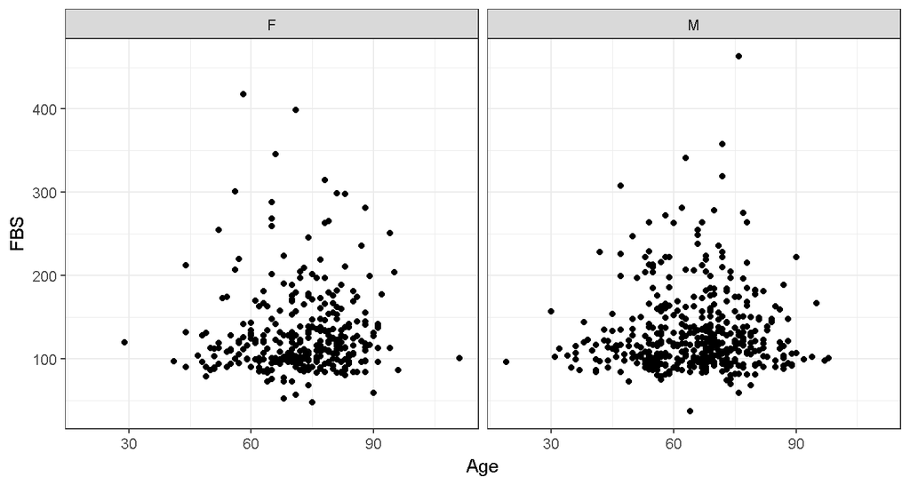

```r
p7 <- ggplot(db, aes(x=Age, y=FBS))
p7 + geom_point() + facet_wrap(~Gender_F) + theme_bw()
```

## Label

- ggtitle("New title")
- xlab("New x label")
- ylab("New y label")

## Exercise 2

- using db named mtcars or your own db file
- make the following graph

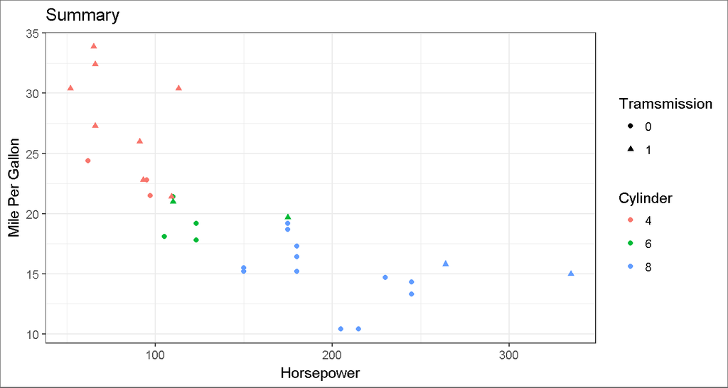